# Appendix D. Cumulative impacts of mining and wind power development on reindeer: calving-site selection data and analysis

Abstract

Here we present a detailed description of the data, methods, and results related to the calving-site selection analysis for reindeer under the presence of the mine and the wind turbines in the Malå reindeer herding district in Sweden. The calving site is the location where the female gives birth and spends time with the calf outside the herd to create an attachment bond. Taking into account different zone of influence (ZOI) radii for mining and different scales for the topographic position index, we fitted a total of 21 candidate models for calving-site selection and compared them through model selection procedures. We report: (i) the method to assess calving period and site identification; (ii) the description of the statistical models of cumulative impacts; (iii) the model selection table comparing the structure and likelihood of the different models; (iv) the analysis of calving site selection and forage quality.

# 1 Figure D1: Calving period and site identification

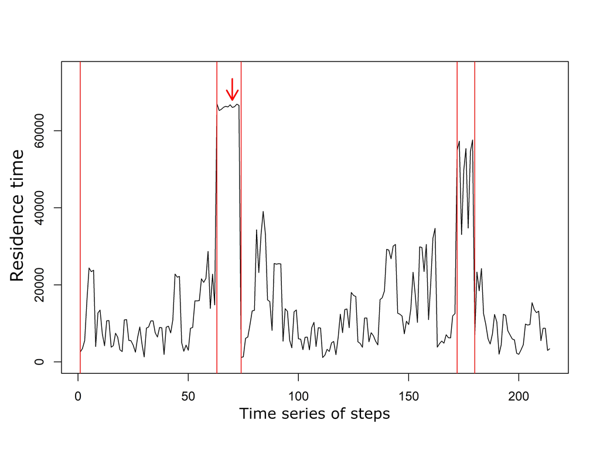

Figure D1. Example of residence time time series employed to find the calving period and calving sites using the function residenceTime() from the recurse package. The most probable calving period lies under the red arrow, between the second and third red lines, corresponding to the group of reindeer positions that includes the first-highest peak of the time series. The grouping was performed using the lavielle() and findpath() functions from the adehabitatLT package in R. The calving site was the mean location where calving occurred.